# MBA em Gestão Estratégica em Banking - In Company Banrisul - UNISINOS

- Estatística e econometria para gestão de risco de crédito e da formação da carteira de investimentos
- Ano/Semestre: 2020/1
- Professor: Prof. Msc. Davi Souza Simon

### Status

- Revisão de conceitos básicos - ok!
- Estatística Descritiva - ok!
- Teste de Hipóteses
- Regressão Linear
- Regressão Logística
- R e RStudio

### Teste de hipóteses

https://www.openintro.org/stat/textbook.php [http://www-bcf.usc.edu/~gareth/ISL/ISLR%20Seventh%20Printing.pdf](http://www-bcf.usc.edu/%7Egareth/ISL/ISLR%20Seventh%20Printing.pdf)

### Teste de hipóteses

Na aula anterior, discutimos brevemente a importância da distribuição normal. O teorema do limite central reforça a utilidade da distrbuição normal. Se tomarmos diversas amostras de uma população, e calcularms as médias de cada amostra, o conjunto de médias amostrais será distribuído de forma normal. Essa propriedade independe da forma da distribuição original!

```r
set.seed(2017)
s <- rbinom(1000, 100, 0.5)
s
```

[output not shown]

[output cut: 27 more lines]

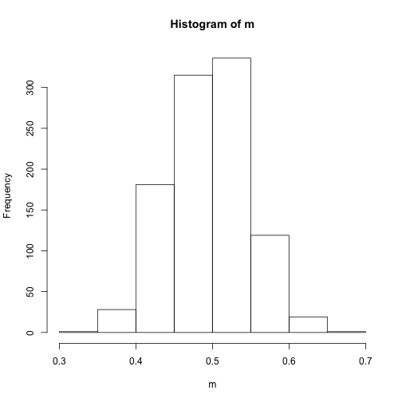

```r
m <- s / 100
hist(m)
```

### Teste de hipóteses

- Uma função para testar o Teorema do Limite Central
- https://www.r-bloggers.com/sampling-distributions-and-central-limit-theorem-in-r/

```r
sdm.sim <- function(n,src.dist=NULL,param1=NULL,param2=NULL) {
   r <- 10000  # Number of replications/samples - DO NOT ADJUST
   # This produces a matrix of observations with
   # n columns and r rows. Each row is one sample:
   my.samples <- switch(src.dist,
    "E" = matrix(rexp(n*r,param1),r),
    "N" = matrix(rnorm(n*r,param1,param2),r),
    "U" = matrix(runif(n*r,param1,param2),r),
    "P" = matrix(rpois(n*r,param1),r),
    "C" = matrix(rcauchy(n*r,param1,param2),r),
  "B" = matrix(rbinom(n*r,param1,param2),r),
    "G" = matrix(rgamma(n*r,param1,param2),r),
    "X" = matrix(rchisq(n*r,param1),r),
    "T" = matrix(rt(n*r,param1),r))
   all.sample.sums <- apply(my.samples,1,sum)
   all.sample.means <- apply(my.samples,1,mean)
   all.sample.vars <- apply(my.samples,1,var)
   par(mfrow=c(2,2))
   hist(my.samples[1,],col="gray",main="Distribution of One Sample")
   hist(all.sample.sums,col="gray",main="Sampling Distribution of
    the Sum")
   hist(all.sample.means,col="gray",main="Sampling Distribution of the Mean")
   hist(all.sample.vars,col="gray",main="Sampling Distribution of
    the Variance")
}
```

### Teste de hipóteses

- https://en.wikibooks.org/wiki/R_Programming/Probability_Distributions

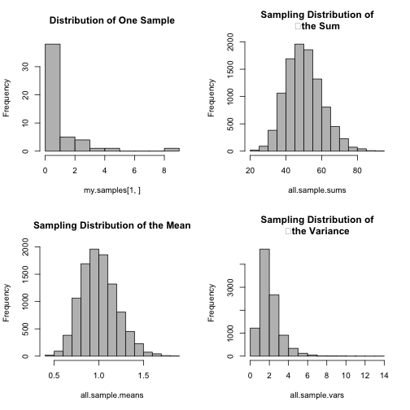

```r
sdm.sim(50,src.dist="X",param1=1)
```

### Desvio padrão x Erro padrão

Desvio padrão é uma medida de dispersão dos dados em relação à média

```r
set.seed(20151204)
#compute the standard deviation
x<-rnorm(1000,20,7)
mean(x)
```

```
[1] 19.95743
```

```r
sd(x)
```

```
[1] 6.920403
```

### Desvio padrão x Erro padrão

Erro Padrão é uma medida de precisão quanto à nossa estimativa de média, em amostragens.

```r
#computation of the standard error of the mean
sem<-sd(x)/sqrt(length(x))
#aprox. 95% confidence intervals of the mean
c(mean(x)-2*sem,mean(x)+2*sem)
```

```
[1] 19.51975 20.39512
```

### Desvio padrão x Erro padrão

- O erro padrão é utilizado para a geração de intervalos de confiança sobre médias estimadas. Segue a regra 68-95-99.7 de probabilidade, mas para a média, e não para os dados.
- Por exemplo, se o intervalo de 95% de confiança de medições produtividade de trabalhadores que recebem bônus não cruza a média de produtividade de trabalhadores que não recebem bônus, então as produtividades são diferentes.
- O erro padrão é dependente do tamanho da amostra. Quando a amostra tende ao infinito, o erro padrão tende a zero.

### Teste de hipóteses

A distribuição das médias amostrais é aproximada razoavelmente por um modelo Normal \[ \bar{x} \sim N ({ mean = \mu, SE = \frac{\sigma}{\sqrt{n}} }), \] no qual o SE representa o *standard error*, definido como o desvio padrão da distribuição amostral Quando o \( \sigma \) não é conhecido, usamos \( s \).

- Quando aumentamos o tamanho da amostra, esperamos que as amostras tenham médias mais consistentes, diminuindo a variabilidade entre as médias.

### Teste de hipóteses

o CLT depende de algumas condições:

\( Independencia \): As observações de uma amostra devem ser independentes, o que é mais provável quando:

- a coleta é realizada de forma aleatória, e
- se a amostra é realizada sem “replacement”“, \( n \) \( < \) 10% da população.

### Teste de hipóteses

*Tamanho da amostra/assimetria*: Ou a população tem distribuição normal, ou se a distribuição é assimétrica, o tamanho da amostra é grande.

-quanto mais assimétrica a distribuição da população, maior o tamanho necessário para que a amostra nos leve a uma aplicação do CLT.

-para distribuições moderadamete assimétricas, \( n>30 \) é uma regra bastante razoável

O problema é: sabemos o quão assimétrica a população é? Testar a população é custoso.

### Intervalo de Confiança

Ciência é difícil. Para a tomada de decisão com base em evidências, precisamos entender as limitações da análise estatística.

[figure not shown]

fonte: https://www.openintro.org/download.php?file=os2_slides_04&referrer=/stat/slides.php

### Intervalo de Confiança

Ao invés de estimarmos um número específico e definitivo, é mais razoável que nossa análise resulte em um possível intervalo de valores para o número que estamos tentando medir. Chamamos esse intervalo de *intervalo de confiança*

### Intervalo de Confiança

- O objetivo de estimar um número exato é como pescar no mar com um arpão. Usar um intervalo de confiança é como usar uma rede.
- Se reportamos uma estimativa média, provavelmente não acertaremos. Se reportarmos um intervalo de possíveis valores, temos uma boa chance de capturar a informação que queremos.

### Intervalo de Confiança

Perguntamos a uma amostra aleatória de 50 estudantes universitários quantas disciplinas que envolvem cálculos matemáticos eles cursaram. A amostra gerou uma média de 3.2 e um desvio padrão de 1.74. Vamos estimar a média da população usando esta amostra.

\[ \bar{x} = 3.2 \qquad s = 1.74 \]

### Intervalo de Confiança

O intervalo de confiança de 95% é definido da seguinte forma:

\[ point~estimate \pm 2 \times SE \]

\[ SE = \frac{s}{\sqrt{n}} = \frac{1.74}{\sqrt{50}} \approx 0.25 \]

\[ \bar{x} \pm 2 \times SE \]

\[ 3.2 \pm 2 \times 0.25 \]

\[ {2.7 , 3.7} \]

### Intervalo de Confiança

Fórmula mais rigorosa:

\[ point~estimate\pm z^\star \times SE \]

- Z é uma função do nível de confiança que queremos utilizar
- As amostras devem ser independentes

### Intervalo de Confiança

Em um intervalo de confiança, \( z^\star \times SE \) é chamado de *margem de erro*, e para uma determinada amostra, a margem de erro varia conforme o intervalo de confiança varia.

- Para mudar o intervalo de confiança, ajustamos o \( z^\star \) na fórmula.
- Intervalos de confiança comumente utilizados na prática são 90%, 95%, 98%, and 99%.
- Para um intervalo de confiança de 95%, \( z^\star = 1.96 \).
- Usando a distribuição normal padronizada (\( z \)), é possível encontrar o \( z^\star \) necessário para cada intervalo de confiança.

### Intervalo de Confiança

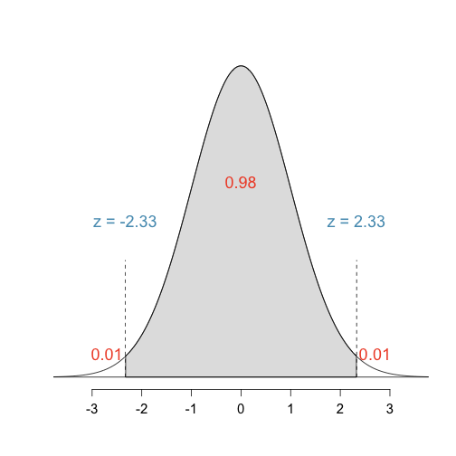

### Intervalo de Confiança

```r
qnorm(0.95)
```

```
[1] 1.644854
```

```r
qnorm(0.01)
```

```
[1] -2.326348
```

```r
qnorm(0.99)
```

```
[1] 2.326348
```

### Teste de Hipóteses

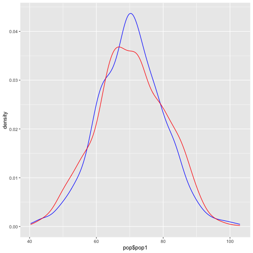

```r
set.seed(2017)
pop <- data.frame(1:1000)
pop$pop1 <- rnorm(1000,70,10)
pop$pop2 <- rnorm(1000,70.5,10.5)
ggplot(data=pop) + geom_density(aes(pop$pop1), color="blue") + geom_density(aes(pop$pop2), color="red")
```

### Teste de Hipóteses

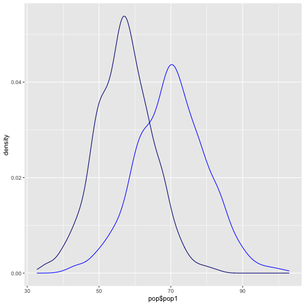

```r
pop$pop1Teste <- pop$pop1 * (1 - (0.10 * rnorm(1,1,1)))
pop$pop2Placebo <- pop$pop2 * (1- (0.02 * rnorm(1,1,1)))
g <- ggplot(data=pop) + geom_density(aes(pop$pop1), color="blue") + geom_density(aes(pop$pop1Teste), color="navy")
g
```

### Teste de Hipóteses

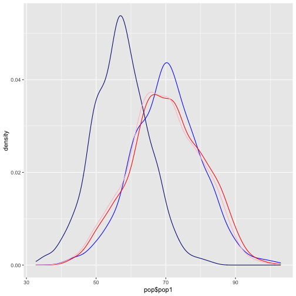

```r
g <- ggplot(data=pop) + geom_density(aes(pop$pop1), color="blue") + geom_density(aes(pop$pop2), color="red") + geom_density(aes(pop$pop1Teste), color="navy") + geom_density(aes(pop$pop2Placebo), color="pink")
g
```

### Teste de Hipóteses

```r
t.test(pop$pop1,pop$pop2)
```

```
    Welch Two Sample t-test

data:  pop$pop1 and pop$pop2
t = -0.31844, df = 1989.9, p-value = 0.7502
alternative hypothesis: true difference in means is not equal to 0
95 percent confidence interval:
 -1.0358023  0.7464176
sample estimates:
mean of x mean of y
 70.26717  70.41187
```

### Teste de Hipóteses

```r
t.test(pop$pop1,pop$pop1Teste)
```

```
    Welch Two Sample t-test

data:  pop$pop1 and pop$pop1Teste
t = 33.09, df = 1916.7, p-value < 2.2e-16
alternative hypothesis: true difference in means is not equal to 0
95 percent confidence interval:
 12.46130 14.03152
sample estimates:
mean of x mean of y
 70.26717  57.02076
```

### Teste de Hipóteses

```r
t.test(pop$pop2,pop$pop2Placebo)
```

```
    Welch Two Sample t-test

data:  pop$pop2 and pop$pop2Placebo
t = 2.0326, df = 1997.6, p-value = 0.04222
alternative hypothesis: true difference in means is not equal to 0
95 percent confidence interval:
 0.03326726 1.85929351
sample estimates:
mean of x mean of y
 70.41187  69.46559
```

### Teste de Hipóteses

Uma pesquisa similar perguntou a quantidade de empresas cobertas por analistas de investimento. 206 analistas responderam a pesquisa, e na média, o analista típico cobriu 9.7 empresas, com desvio padrão de 7.

Pesquisas científicas mostram que a capacidade de atenção do analista é limitada, e quanto mais empresas ele cobre, menor a precisão de sua análise. Esses estudos recomendam que o analista cubra no máximo 8 empresas.

### Teste de Hipóteses

Os dados da nossa pesquisa trazem evidências convincentes de que o número médio de empresas cobertas pelos analistas é maior do que o recomendado?

### Teste de Hipóteses

Há duas explicações concorrentes para a diferença entre a média da amostra e nosso número de referência: -a média real da população é diferente de 8. -a média real da população é 8, e a diferença entre a média real e a média da amostra decorre de pura variabilidade amostral.

### Teste de Hipóteses

Partimos da premissa de que o número médio de empresas cobertas pelos analistas é 8 (como recomendado) \[ {H_0:}~\mu = 8 \]

Testamos a hipótese de que o número de empresas cobertas é maior do que 8 \[ {H_A:}~\mu > 8 \]

### Teste de Hipóteses

Para avaliar se a média amostral é não usual para a distribuição amostral hipotética, determinamos a distância da média amostral para a média hipotética, em termos de desvios padrão. Chamamos essa distância normalizada de *test statistic*.

### Teste de Hipóteses

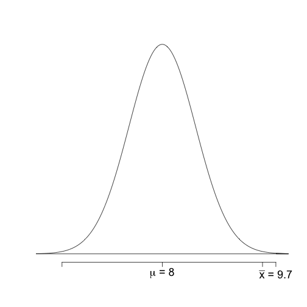

### Teste de Hipóteses

\[ \bar{x} \sim N ({ \mu = 8, SE = \frac{7}{\sqrt{206}} = 0.5 )} \] \[ Z = \frac{9.7 - 8}{0.5} = 3.4 \]

A média da amostra está 3.4 standard errors distante do valor hipotético. Essa distância é não usual? Ao respoder essa pergunta, buscamos responder se nosso resultado é estatisticamente significante.

### Teste de Hipóteses

- Usamos o *test statistic* para calcular o *p-value*, a probabilidade de observarmos dados tão favráveis à hipótese alternativa se a hipótese nula fosse verdadeira.
- Se o p-value é baixo (mais baixo de que o nível de significância, \( \alpha \), usualmente 5%), assumimos que seria muito improvável observarmos os dados que coletamos se a hipótese nula fosse verdadeira. Assim, o que fazemos é rejeitar \( H_0 \).
- Se o p-value é maior que \( \alpha \), assumimos que nossos dados não são improváveis mesmo que a hipótese nula fosse verdadeira. Assim, não podemos rejeitar \( H_0 \).

### Teste de Hipóteses

- Por que o \( \alpha \) de 5% é usado?
- Ciências sociais aplicadas
- Engenharia aerospacial, Física de partículas, Medicina

### Teste de Hipóteses

*p-value*: probabilidade de observarmos dados tão favoráveis a \( H_A \) quanto os dados na nossa amostera (média de 9.7), se de fato \( H_0 \) fosse verdade (a média real da população é 8).

\[ P(\bar{x} > 9.7~|~\mu = 8) = P(Z > 3.4) = 0.0003 \]

Se a média real de empresaa cobertas por analistas é 8, há apenas uma chance de 0.03% de observarmos, em uma amostra aleatória de 206 analistas, uma cobertura média de 9,7 empresas.

Essa probabilidade é razoavelmente baixa. Podemos concluir que há algo de errado com os analistas?

### Teste de Hipóteses

Uma pesquisa realizada médica sobre qualidade do sono revelou que as pessoas dormem em média 7 horas por noite. Em uma amostra de 169 estudantes de MBA, verificou-se que a média de horas dormidas é 6.88 horas, com um desvio padrão de 0.94 horas.

Um teste de hipóteses foi conduzido para avaliar se os estudantes de MBA dormem em média menos de 7 horas por noite. O p-value do teste foi de 0.0485.

### Teste de Hipóteses

\[ \bar{x} \sim N ({ \mu = 7, SE = \frac{0.94}{\sqrt{169}} = 0.07 )} \]

```r
pnorm(-1.6595)
```

```
[1] 0.04850754
```

### Teste de Hipóteses

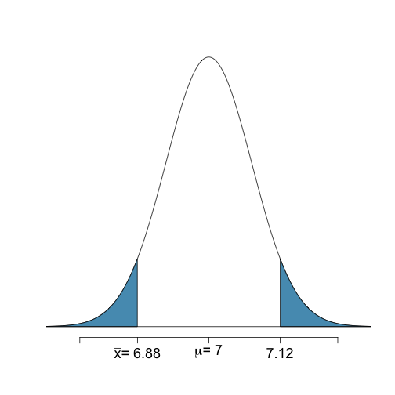

### Pausa para reflexão

- Em um teste de hipóteses, temos duas hipóteses competindo. A hipótese nula e a hipótese alternativa.
- Partimos do pressuposto de que a hipótese nula e verdadeira, e analisamos se nossos dados rejeitam essa hipótese.
- Popper - A Lógica da pesquisa científica, Cisne Negro, Pesquisas sobre o ovo, o café, etc.
- Lógica frequentista x Lógica Bayesiana

### Teste de Hipóteses

Em um teste de hipóteses, fazemos uma decisão com base em métodos e dados imperfeitos. Nossa escolha pode estar errada.

Um *Erro Tipo 1* acontece se rejeitamos a hipótese nula mas \( H_0 \) é verdade.

Um *Erro Tipo 2* acontece se não rejeitamos a hipótese nula, mas \( H_A \) é verdade.

Nós quase nunca sabemos de antemão se \( H_0 \) ou \( H_A \) é verdade, e precisamos considerar todas as possibilidades.

### Teste de Hipóteses

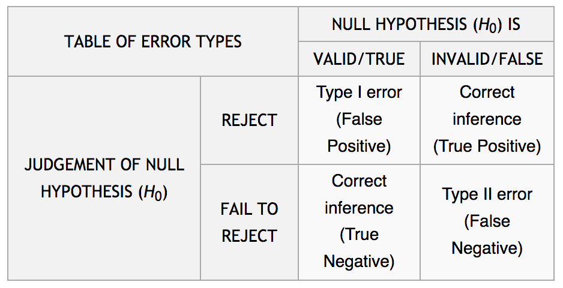

fonte: https://www.r-bloggers.com/my-note-on-multiple-testing/

https://www.ncbi.nlm.nih.gov/pmc/articles/PMC4401675/

### Mais reflexão

Suponha que uma em 10.000 pessoas visitando Fernando de Noronha por uma semana pegue Dengue. Há um teste para Dengue que tem 99,9% de precisão. Então, se você testa positivo, isso significa problemas, certo?

### Mais reflexão

- Se todos os 10.000 visitantes realizarem o teste, na média 1 pessoa deveria testar positivo e 9.999 negativo.
- Contudo, quando as 9.999 pessoas relizam um teste que é 99,9% preciso, teremos 10 falsos positivos. Somemos esses 10 falsos positivos ao positivo real, e temos 11 pessoas identificadas como doentes.
- Então, se o seu teste deu positivo, suas chances de estar doente são de 1/11, ou 9%.

fonte: http://www.worldsciencefestival.com/2015/06/wizards-odds-3/

### Mais reflexão

Paradoxo dos Falsos Positivos

*The phrase ‘false positive paradox’ describes our primary findings. When the incidence of any given condition is lower than a test's false positive rate, even tests that have a high specificity (i.e., low chance of giving a false positive in an individual case) will generate more false than true positives.*

### Mais reflexão

Paradoxo do Promotor

https://en.wikipedia.org/wiki/Prosecutor%27s_fallacy

### Teste de Hipóteses

Como regra geral, rejeitamos \( H_0 \) quando o p-valor é inferior a 0.05, i.e. usamos um nível de significância de 0.05, \( \alpha = 0.05 \).

Para os casos em que \( H_0 \) é a hipótese verdadeira, não queremos incorretamente rejeitá-la mais do que 5% das vezes.

Com um critério de significância de 5%, há aproximadamente 5% de chance de incorrermos em um erro do tipo 1 quando a hipótese nula é verdadeira. \[ { P(\text{Type 1 error}) = \alpha } \]

### Teste de Hipóteses

- A escolha de um nível de significância para um teste é importante em diversos contextos. 5% é um critério mínimo e geralmente aceito em ciências sociais aplicadas.
- Em aplicações de pesquisa média, física, etc, mais rigor é requerido, o que leva a critérios mais exigentes.

### Teste de Hipóteses

- Quando cometer um erro do tipo 1 é muito perigoso e custoso, escolhemos um nível de significância mais restritivo (e.g. 0.01). Nesse cenário, demandamos evidências muito fortes para aceitar a \( H_A \) em detrimento de \( H_0 \).
- Em outros casos, um erro tipo 2 pode ser mais perigoso que um erro tipo 1. Nesse caso, podemos usar um nóvel de significância mais alto (e.g. 0.10). Um teste de identificação de uma doença, quando tratar é mais barato mesmo que se trate de um falso positivo.

### Teste de Hipóteses

Resumo:

- Definimos a hipótese de interesse
- \( H_0: \mu = null~value \)
- \( H_A: \mu < \) or \( > \) or \( \ne null~value \)
- Calculamos a estimativa

### Teste de Hipóteses

Premissas e condições

- Independencia: amostra aleatória, não mais que 10% da população
- Normalidade: população com distribuição aproximadamente normal ou \( n \ge 30 \), sem assimetria extrema (ou distribuição T de Student)

Calculamos uma estatística de teste e obtemos o p-value:

\[ Z = \frac{\bar{x} - \mu}{SE},~where~SE = \frac{s}{\sqrt{n}} \]

### Teste de Hipóteses

Tomamos uma decisão e a interpretamos de acordo com o contexto:

- se o p-value \( < \alpha \), rejeitamos \( H_0 \), pois os dados provém evidência favorável para \( H_A \)
- se o p-value \( > \alpha \), não rejeitamos \( H_0 \), pois dados não apresentam evidências suficientes em favor de \( H_A \)

### Teste de Hipóteses

https://www.vox.com/science-and-health/2017/7/31/16021654/p-values-statistical-significance-redefine-0005

### Tamanho da amostra

Nossos objetivos podem ajudar a definir o tamanho da amostra que necessitamos.

Um grupo de pesquisadores quer testar o efeito de um novo fertilizante na produtividade de fazendas que produzem soja. Como evidência, eles querem estimar a produtividade de fazendas que adotaram recentemente o fertilizante. Estudos em laboratório mostraram que o desvio padrão na produtividade por hectare era de 18 sacas. Quantas fazendas precisam ser utilizadas na amostra para que seja possível obter um intervalo de confiança de 96%, resultando em uma margem de erro de 4 sacas?

\[ 4 \ge z^\star * sd / \sqrt{n} \]

### Tamanho da amostra

Sabemos que o valor crítico associado com o intervalo de confiânça de 96% (2% para cima e 2% para baixo) é igual a \( z^\star = 2.05 \).

\[ 4 \ge 2.05 * 18 / \sqrt{n} \rightarrow n \ge (2.05 * 18 / 4)^2 = 85.1 \]

A quantidade mínima de fazendas que devem integrar o estudo para que a margem de erro desejada seja atingida é de 85.1 fazendas.

### Exercício

- A empresa RMB Laminados produz pisos laminados de MDF. Sua matéria prima é altamente homogênea, e tem um histórico de rendimento razoavelmente confiável.
- Eles adquiriram uma nova máquina que faz a aglutinação de resíduos de madeira, supostamente de modo mais eficiente, aumentando a produtividade a partir da mesma quantidade de matéria prima.

### Exercício

Historicamente, a empresa produz 100m3 de produto pronto para cada 1 tonelada de matéria prima, com desvio padrão de 10m3.

Os dados da produção do último período, considertando os 1000 lotes com máquinas antigas, e 500 lotes em máquinas novas, constam do arquivo “dadosProd.xlsx”

Com base nos dados de produção, podemos concluir, com base em \( \alpha \) de 1%, que a nova máquina é mais eficiente que as máquinas antigas?

### Exercício

Importando os dados

```r
DadosAntigas <- read_excel("dadosProd.xlsx",sheet=1, col_names = TRUE, col_types = NULL, na = "-", skip = 0)
DadosNovas <- read_excel("dadosProd.xlsx",sheet=2, col_names = TRUE, col_types = NULL, na = "-", skip = 0)
```

### Exercício

```r
summary(DadosAntigas)
```

```
      Lote        Máquinas Antigas
 Min.   :   1.0   Min.   : 65.82
 1st Qu.: 250.8   1st Qu.: 94.19
 Median : 500.5   Median :100.93
 Mean   : 500.5   Mean   :100.63
 3rd Qu.: 750.2   3rd Qu.:107.24
 Max.   :1000.0   Max.   :133.33
```

```r
sd(DadosAntigas$`Máquinas Antigas`)
```

```
[1] 9.686366
```

```r
summary(DadosNovas)
```

```
      Lote      Máquinas Novas
 Min.   :1001   Min.   : 52.27
 1st Qu.:1126   1st Qu.: 93.07
 Median :1250   Median :103.95
 Mean   :1250   Mean   :105.32
 3rd Qu.:1375   3rd Qu.:117.28
 Max.   :1500   Max.   :158.50
```

```r
sd(DadosNovas$`Máquinas Novas`)
```

```
[1] 17.72474
```

### Análise Visual

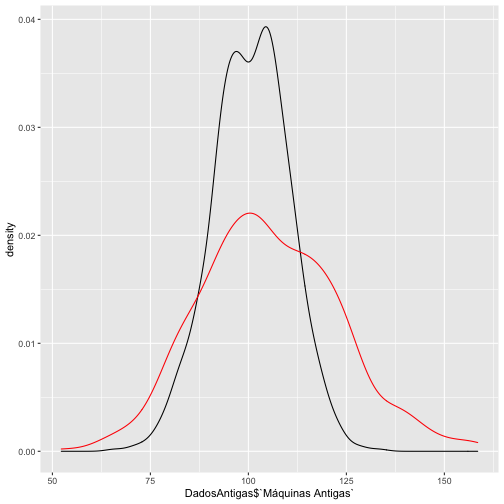

```r
ggplot() + geom_density( aes(x=DadosAntigas$`Máquinas Antigas`)) + geom_density( aes(x=DadosNovas$`Máquinas Novas`),color="red")
```

### Rigor

Usar o comendo *help(t.test)* digitado no console para inspecionar a função.

Definir:

- \( H_0: \mu = null~value \)
- \( H_A: \mu < \) or \( > \) or \( \ne null~value \)

### Solução

```r
t.test(DadosNovas$`Máquinas Novas`,DadosAntigas$`Máquinas Antigas`, alternative="greater", conf.level = 0.99)
```

```
    Welch Two Sample t-test

data:  DadosNovas$`Máquinas Novas` and DadosAntigas$`Máquinas Antigas`
t = 5.5159, df = 651.89, p-value = 2.504e-08
alternative hypothesis: true difference in means is greater than 0
99 percent confidence interval:
 2.705615      Inf
sample estimates:
mean of x mean of y
 105.3191  100.6317
```

### Solução

-Assumimos que a hipótese nula é verdadeira, de que ambos os grupos de máquinas tem a mesma média de produção.

-Tirarmos amostras aleatórias das máquinas novas e máquinas antigas (constam dos arquivos xls).

-A diferença de média é suficiente para que não possamos afirmar que as máquinas antigas são tão eficientes quanto as máquinas novas (p<0.05).

-Há ganho de eficiência.